# es() - Exponential Smoothing

Ivan Svetunkov

2016-09-16

`es()` is a part of smooth package. It allows constructing Exponential Smoothing (also known as ETS), selecting the most appropriate one among 30 possible ones, including exogenous variables and many more.

In this vignette we will use data from `Mcomp` package, so it is adviced to install it.

Let’s load the necessary packages:

```r
require(smooth)
require(Mcomp)
```

You may note that `Mcomp` depends on `forecast` package and if you load both `forecast` and `smooth`, then you will have a message that `forecast()` function is masked from the environment. There is nothing to be worried about - `smooth` uses this function for consistency purposes and has exactly the same original `forecast()` as in the `forecast` package. The inclusion of this function in `smooth` was done only in order not to include `forecast` in dependencies of the package.

The simplest call of this function is:

```r
es(M3$N2457$x, h=18, holdout=TRUE)
```

```
## Forming the pool of models based on... ANN, ANA, AAN, Estimation progress:    100%... Done!
```

```
## Time elapsed: 0.35 seconds
## Model estimated: ETS(MNN)
## Persistence vector g: 0.145
## Initial values were optimised.
## 3 parameters were estimated in the process
## Residuals standard deviation: 0.413
## Cost function type: MSE; Cost function value: 1288657
##
## Information criteria:
##      AIC     AICc      BIC
## 1645.978 1646.236 1653.702
##
## Forecast errors:
## MPE: 26.3%; Bias: 87%; MAPE: 39.8%; SMAPE: 49.4%
## MASE: 2.944; sMAE: 120.1%; RelMAE: 1.258; sMSE: 242.7%
```

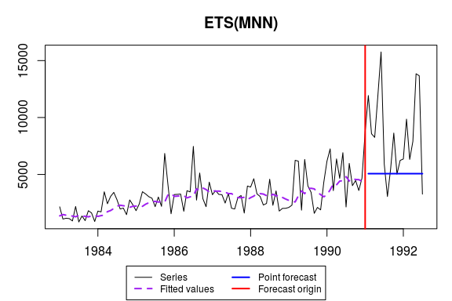

In this case function uses branch and bound algorithm to form a pool of models to check and after that constructs a model with the lowest information criterion. As we can see, it also produces an output with brief information about the model, which contains:

1. How much time was elapsed for the model construction;
2. What type of ETS was selected;
3. Values of persistence vector (smoothing parameters);
4. What type of initialisation was used;
5. How many parameters were estimated (standard deviation is included);
6. Standard deviation of residuals. The model has multiplicative error term, so as a result the standard deviation is small.
7. Cost function type and the value of that cost function;
8. Information criteria for this model;
9. Forecast errors (because we have set `holdout=TRUE`).

The function has also produced a graph with actuals, fitted values and point forecasts.

If we need prediction intervals, then we run:

```r
es(M3$N2457$x, h=18, holdout=TRUE, intervals=TRUE)
```

```
## Forming the pool of models based on... ANN, ANA, AAN, Estimation progress:    100%... Done!
```

```
## Time elapsed: 0.34 seconds
## Model estimated: ETS(MNN)
## Persistence vector g: 0.145
## Initial values were optimised.
## 3 parameters were estimated in the process
## Residuals standard deviation: 0.413
## Cost function type: MSE; Cost function value: 1288657
##
## Information criteria:
##      AIC     AICc      BIC
## 1645.978 1646.236 1653.702
##
## 95% parametric prediction intervals were constructed
## 72% of values are in the prediction interval
## Forecast errors:
## MPE: 26.3%; Bias: 87%; MAPE: 39.8%; SMAPE: 49.4%
## MASE: 2.944; sMAE: 120.1%; RelMAE: 1.258; sMSE: 242.7%
```

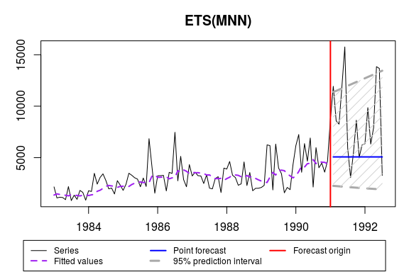

Due to multiplicative nature of error term in the model, the intervals are asymmetric. This is the expected behaviour. The other thing to note is that the output now also provides the theoretical width of prediction intervals and its actual coverage.

If we save the model (and let’s say we want it to work silently):

```r
ourModel <- es(M3$N2457$x, h=18, holdout=TRUE, silent="all")
```

we can then reuse it for different purposes:

```r
es(M3$N2457$x, model=ourModel, h=18, holdout=FALSE, intervals=TRUE, intervalsType="n", level=0.93)
```

```
## Time elapsed: 0.1 seconds
## Model estimated: ETS(MNN)
## Persistence vector g: 0.145
## Initial values were provided by user.
## 3 parameters were estimated in the process
## Residuals standard deviation: 0.434
## Cost function type: MSE; Cost function value: 1965686
##
## Information criteria:
##      AIC     AICc      BIC
## 1998.861 1999.078 2007.096
##
## 93% nonparametric prediction intervals were constructed
```

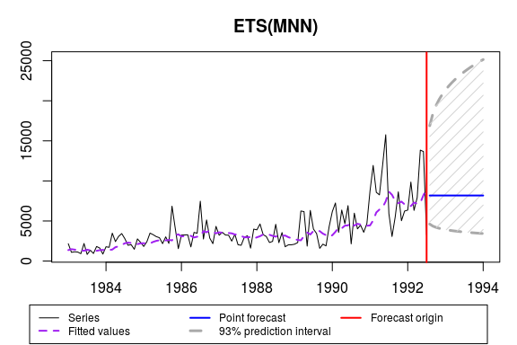

Or we can just use persistence or initials from one model to construct the other one:

```r
es(M3$N2457$x, model="MNN", h=18, holdout=FALSE, initial=ourModel$initial, silent="graph")
```

```
## Time elapsed: 0.02 seconds
## Model estimated: ETS(MNN)
## Persistence vector g: 0.151
## Initial values were provided by user.
## 3 parameters were estimated in the process
## Residuals standard deviation: 0.434
## Cost function type: MSE; Cost function value: 1965401
##
## Information criteria:
##      AIC     AICc      BIC
## 1998.845 1999.061 2007.079
```

```r
es(M3$N2457$x, model="MNN", h=18, holdout=FALSE, persistence=ourModel$persistence, silent="graph")
```

```
## Time elapsed: 0.04 seconds
## Model estimated: ETS(MNN)
## Persistence vector g: 0.145
## Initial values were optimised.
## 3 parameters were estimated in the process
## Residuals standard deviation: 0.434
## Cost function type: MSE; Cost function value: 1965686
##
## Information criteria:
##      AIC     AICc      BIC
## 1998.861 1999.078 2007.096
```

or provide some arbitrary values:

```r
es(M3$N2457$x, model="MNN", h=18, holdout=FALSE, initial=1500, silent="graph")
```

```
## Time elapsed: 0.03 seconds
## Model estimated: ETS(MNN)
## Persistence vector g: 0.15
## Initial values were provided by user.
## 3 parameters were estimated in the process
## Residuals standard deviation: 0.435
## Cost function type: MSE; Cost function value: 1968546
##
## Information criteria:
##      AIC     AICc      BIC
## 1999.029 1999.245 2007.263
```

Using some other parameters may lead to completely different model and forecasts:

```r
es(M3$N2457$x, h=18, holdout=TRUE, cfType="aMSTFE", bounds="a", ic="BIC", intervals=TRUE)
```

```
## Forming the pool of models based on... ANN, ANA, AAN, Estimation progress:    100%... Done!
```

```
## Time elapsed: 1.16 seconds
## Model estimated: ETS(MNN)
## Persistence vector g: 0.08
## Initial values were optimised.
## 3 parameters were estimated in the process
## Residuals standard deviation: 0.42
## Cost function type: aMSTFE; Cost function value: 246
##
## Information criteria:
##      AIC     AICc      BIC
## 25551.52 25556.16 25690.55
##
## 95% parametric prediction intervals were constructed
## 72% of values are in the prediction interval
## Forecast errors:
## MPE: 33.3%; Bias: 90.4%; MAPE: 43.3%; SMAPE: 56.3%
## MASE: 3.232; sMAE: 131.9%; RelMAE: 1.381; sMSE: 277.6%
```

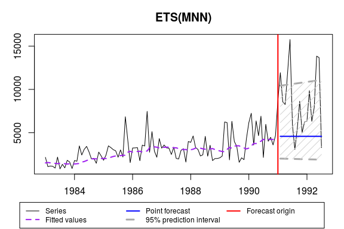

You can play around with all the available parameters to see what’s their effect on final model.

Model selection from a specified pool and forecasts combination are called using respectively:

```r
es(M3$N2457$x, model=c("ANN","AAN","AAdN","ANA","AAA","AAdA"), h=18, holdout=TRUE, silent="graph")
```

```
## Estimation progress:    17%33%50%67%83%100%... Done!
```

```
## Time elapsed: 0.67 seconds
## Model estimated: ETS(ANN)
## Persistence vector g: 0.158
## Initial values were optimised.
## 3 parameters were estimated in the process
## Residuals standard deviation: 1439.368
## Cost function type: MSE; Cost function value: 2007705
##
## Information criteria:
##      AIC     AICc      BIC
## 1688.987 1689.245 1696.711
##
## Forecast errors:
## MPE: 25.3%; Bias: 86%; MAPE: 39.4%; SMAPE: 48.6%
## MASE: 2.909; sMAE: 118.7%; RelMAE: 1.243; sMSE: 238.1%
```

```r
es(M3$N2457$x, model="CCN", h=18, holdout=TRUE, silent="graph")
```

```
## Estimation progress:    10%20%30%40%50%60%70%80%90%100%... Done!
```

```
## Time elapsed: 0.89 seconds
## Model estimated: ETS(CCN)
## Initial values were optimised.
## Residuals standard deviation: 0.414
## Cost function type: MSE
##
## Information criteria:
## Combined AICc
##      1647.505
##
## Forecast errors:
## MPE: 24.1%; Bias: 84.9%; MAPE: 39.2%; SMAPE: 47.9%
## MASE: 2.878; sMAE: 117.4%; RelMAE: 1.229; sMSE: 234%
```

Now let’s introduce some artificial exogenous variables:

```r
x <- cbind(rnorm(length(M3$N2457$x),50,3),rnorm(length(M3$N2457$x),100,7))
```

and fit a model with exogenous without update first:

```r
es(M3$N2457$x, model="ZZZ", h=18, holdout=TRUE, xreg=x)
```

```
## Forming the pool of models based on... ANN, ANA, AAN, Estimation progress:    40%50%60%70%80%90%100%... Done!
```

```
## Time elapsed: 1.25 seconds
## Model estimated: ETS(MAN)
## Persistence vector g: 0.909, 0.164
## Initial values were optimised.
## 6 parameters were estimated in the process
## Residuals standard deviation: 0.494
## Xreg coefficients were estimated in a normal style
## Cost function type: MSE; Cost function value: 1782778
##
## Information criteria:
##      AIC     AICc      BIC
## 1683.461 1684.395 1698.910
##
## Forecast errors:
## MPE: -16.3%; Bias: 5.1%; MAPE: 49.3%; SMAPE: 43%
## MASE: 2.645; sMAE: 107.9%; RelMAE: 1.13; sMSE: 162.3%
```

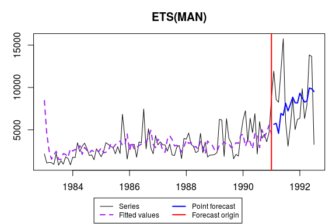

and then with the update:

```r
es(M3$N2457$x, model="ZZZ", h=18, holdout=TRUE, xreg=x, updateX=TRUE)
```

```
## Forming the pool of models based on... ANN, ANA, AAN, Estimation progress:    100%... Done!
```

```
## Time elapsed: 0.63 seconds
## Model estimated: ETS(MNN)
## Persistence vector g: 0.049
## Initial values were optimised.
## 3 parameters were estimated in the process
## Residuals standard deviation: 0.396
## Xreg coefficients were estimated in a crazy style
## Cost function type: MSE; Cost function value: 1185814
##
## Information criteria:
##      AIC     AICc      BIC
## 1637.910 1638.168 1645.634
##
## Forecast errors:
## MPE: 38.7%; Bias: 92.2%; MAPE: 46.1%; SMAPE: 61.9%
## MASE: 3.455; sMAE: 140.9%; RelMAE: 1.476; sMSE: 307.5%
```

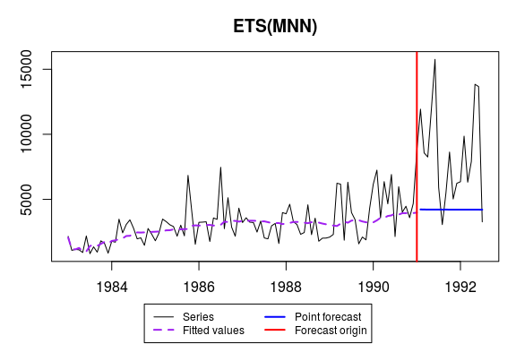

Be careful, however, when non additive ETS models are used with exogenous variables. The results may be highly unsatisfactory and unstable.